# Group 19

## GitHub Repo: https://github.com/andre-gnandt/DATA-550-Lab-Group-19

# DATA 550 Lab 3 (group lab) - Communication visualizations

In this lab we will be using both R and Python, and for each question you will develop an answer both in `ggplot` and in `Altair`. Each partner should choose a version to complete, though keep in mind that **you are required to alternate between completing the R labs and the Python labs** to get experience using both languages.

Although the `%%R` cell magic makes it convenient for us to do this in the same notebook, I would still recommend that you use a separate Jupyter Notebook with a dedicated R kernel or RStudio to develop your R code. The reasons for this are that autocompletion works better there and the error messages are easier to understand. Once you have developed the code for a question you can paste it into the corresponding R cell here and make sure it runs and shows up in the exported HTML.

If your `rpy2` does not work, you can paste in entire cells from an R-kernel including the output plots, or you can submit a different notebook on GitHub for the R part, but you must write this in the canvas comments or next to your repo link in this notebook so that the TAs know when they grade.

## Submission instructions

rubric={mechanics:2}

You receive marks for submitting your lab correctly, please follow these instructions:

- Create a GitHub Repo for your group.
  - Keep this organized, i.e. with a separate clearly marked folder for each assignment.
- [Click here to view a description of the rubrics used to grade the questions](https://github.com/UBC-MDS/public/tree/master/rubric)
- Push your `.ipynb` file to your GitHub repository for this lab.
- Include a clickable link to your GitHub repo for the lab just below this cell
  - It should look something like this https://github.ubc.ca/folder_path/DATA_550_labX_groupY.
- Upload a `.html` version of your assignment to Canvas.
  - Run all cells in your notebook to make sure there are no errors by doing `Kernel -> Restart Kernel and Run All Cells...`
  - Convert your notebook to .html format using `File -> Save and Export Notebook As -> HTML`
  - Submit and double check that your have submitted the correct file to Canvas

```python
# Run this cell to ensure that altair plots show up in the exported HTML
# and that the R cell magic works
import altair as alt

# Save a vega-lite spec and a PNG blob for each plot in the notebook
alt.renderers.enable('mimetype')
# Handle large data sets without embedding them in the notebook
#alt.data_transformers.enable('data_server')
alt.data_transformers.enable("vegafusion")

# Load the R cell magic
%load_ext rpy2.ipython
```

```
Error importing in API mode: ImportError('On Windows, cffi mode "ANY" is only "ABI".')
Trying to import in ABI mode.
```

## 0. So we meet again...

I am sure you have heard, turns out Bestflix did not make it. Copyright issues they said, can you believe it?? I can't, there must have been more to this story... And the only other person with knowledge of this enterprise was... YOU!

In the spirit of a true comic book criminal, I will scale my revenge for this set back completely out of proportion and attempt world dominion. Don't worry, there will be no blood shed, I operate with class so my plan here is to brainwash people into thinking that I am actually good for them and then reap personal benefits once in power, creative isn't it?

To convince the pleb... I mean honorary citizens of the world to vote for me, I have made several key visualizations showing what an ideal candidate I am. The only way to stop me (hmm why am I telling you this again...) is to debunk these visualizations and show voters the errors of my ways (this is clearly a fictional scenario since we are assuming that each person acts rationally and is convinced by data).

Below is my publicly distributed campaign material covering these four main area:

1. The current dramatic increase in job dissatisfaction
2. My previous record on increasing job wages for all
3. Guns to the people
4. My great approval rating

For each figure that I have made, I have also included the underlying data (imagine what a wonderful world it would be if that actually happened in real life...). You can find these datasets in the `lab3/` folder of the course student GitHub repo. For each question in this lab, your team has the following three tasks:

1. Decide if you think my plot and my claim is misleading or not, why you think so, and how you would improve it in your version of the same figure (unless you think mine is already good). In addition to what we are learning this week, you will need to draw on your knowledge from last week for when certain plots are suitable and which are common pitfalls to avoid.
2. To earn the people's trust, you need to recreate my plot to show that you know what I did. This includes axis labels, legends, colors, titles, figure size, everything as close as possible to the images I have pasted for each question below.
3. Create your own better version of the same figure. Make sure that your choices are motivated in writing in point 1.

# 1. Dramatic decline in job satisfaction

## The data

The `cities-job-satisfaction.csv` dataset contains (fictional) data from different cities around the world. In this data it was measured which proportion of people reported that they were unsatisfied with their work situation this year compared to last year. Each data point is a different city, and the value indicates the proportion of dissatisfied workers.

## My plots

### Altair

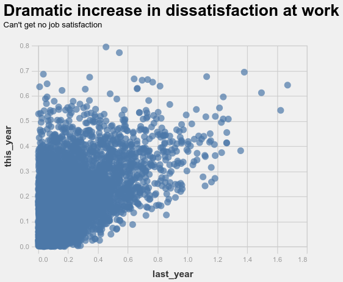

### ggplot

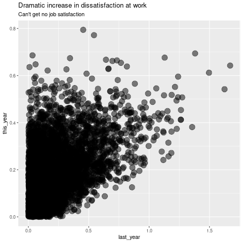

## My claim

You can clearly see in this plot that people are dramatically more dissatisfied at work this year compared to last year. I have used transparency for the dots to prevent overplotting/oversaturation, so this means that the entire dark area has an even amount of cities throughout. In other words, there are as many cities that increased from ~0% to ~40% dissatisfaction as there are cities that stayed around 0%. That's atrocious!

### Question 1.1

rubric={reasoning:2,writing:1}

- Explain which mistakes (if any) I have done in my plot and provide an interpretation of the data that is more correct than mine. Be brief and clear in your answer.
- You might have some ideas just from looking at my plot, but you will likely need to do some investigation yourself to answer this question fully. You can reference your improved plot as needed.

The mistake is assuming that the darkness of the build up transparent circles in a region of the chart can be interpreted as an accurate display of the density or count of cities that have values in that region of the chart. We can't assume that the trasparency accurately reflects the density of the cities. A better approach would be to map the density of the points to color brightness, like in a heatmap. This way we can more accurately visualize the amount of cities that have increased or decreased dissatisfaction levels between last year and this year.

### Question 1.2

rubric={accuracy:2}

#### Python

Recreate the Altair version of the plot. Your plot should look as close as possible to mine in the image above.

```python
# YOUR ANSWER HERE
import pandas as pd
import warnings
warnings.filterwarnings("ignore", category=FutureWarning)
alt.renderers.enable('default')

data = pd.read_csv("cities-job-satisfaction.csv")
data.head()
```

|  | last_year | this_year |
| --- | --- | --- |
| 0 | 0.149837 | 0.105053 |
| 1 | 0.063368 | 0.518310 |
| 2 | 0.181183 | 0.131546 |
| 3 | 0.062719 | 0.160193 |
| 4 | 0.117613 | 0.058185 |

```python
alt.Chart(data).mark_circle(color = 'darkblue', opacity = 0.5, size=250).encode(
    x = alt.X('last_year:Q', axis = alt.Axis(tickCount=9)),
    y = alt.Y('this_year:Q', axis = alt.Axis(tickCount = 8))
).properties(
    title = alt.TitleParams(
        text = "Dramatic increase in dissatisfaction at work",
        subtitle = "Can't get no job satisfaction",
        anchor='start',
        subtitleColor = 'gray'
    ),
    width = 500,
    height=500
).configure_title(
    fontSize = 30
).configure_axis(
    titleFontSize = 16
)
```

[interactive chart not shown]

### Question 1.3

rubric={accuracy:2}

#### R

Recreate my ggplot version of the plot. Your plot should look as close as possible to mine in the image above.

```
In addition: Warning messages:
1: package 'ggplot2' was built under R version 4.5.2
2: package 'tibble' was built under R version 4.5.2
```

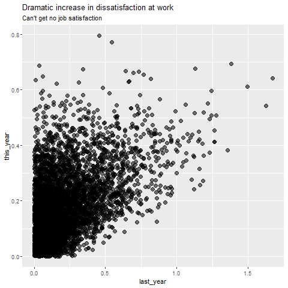

```python
%%R
# YOUR ANSWER HERE

library(tidyverse)

data<- read.csv("cities-job-satisfaction.csv")

ggplot(data, aes(x = last_year, y = this_year)) +
  geom_point(color = "black", alpha = 0.55, size = 3) +
  labs(
    title = "Dramatic increase in dissatisfaction at work",
    subtitle = "Can't get no job satisfaction",
    x = "last_year",
    y = "this_year"
  )
```

### Question 1.4

rubric={viz:2}

#### Python

Improve my Altair plot. Chose the best type of plot to accurately reveal what the data looks like. Design the plot to be an effective plot for communication purposes, this includes proper figure size, axis/figure titles, font sizes, colors, etc.

```python
alt.Chart(data).mark_rect().encode(
    x = alt.X('last_year', bin = alt.Bin(maxbins = 18), title = "Dissatisfaction Proportions last year"),
    y = alt.Y('this_year', bin = alt.Bin(maxbins = 9), title = "Dissatisfaction Proportions this year"),
    color = 'count():Q'

).properties(
    title = alt.TitleParams(
        text = "City dissatisfaction levels last year vs this year",
        anchor='start',
        subtitleColor = 'gray'
    ),
    width = 1000,
    height=500
).configure_title(
    fontSize = 35
).configure_axis(
    titleFontSize = 25
)
```

[interactive chart not shown]

### Question 1.5

rubric={viz:2}

#### R

Improve my ggplot plot. Chose the best type of plot to accurately reveal what the data looks like. Design the plot to be an effective plot for communication purposes, this includes proper figure size, axis/figure titles, font sizes, colors, etc.

[figure not shown]

```python
%%R
# YOUR ANSWER HERE

ggplot(data, aes(x = last_year, y = this_year)) +
  geom_bin2d(bins = 45) +
  labs(
    title = "Job dissatisfaction: This year vs Last year",
    subtitle = "Each tile summarizes many cities, darker tiles indicate higher concentration",
    x = "Dissatisfaction last year",
    y = "Dissatisfaction this year",
    fill = "Number of cities"
  )+
theme_minimal(base_size = 15) +
  theme(
    plot.title = element_text(face = "bold", size = 16),
    plot.subtitle = element_text(size = 12),
    legend.position = "right"
  )
```

# 2. I will keep raising wages for all

## The data

The `wages.csv` dataset contains (fictional) data from different companies in the city where I have been the mayor for the last few years. Each datapoint represents the average salary at a company. All the major companies in this city were surveyed both before I was elected and after a few years of my governing. However, this is not paired data, some companies are different from "before" and "after", so you do not need to do a paired analysis.

## My plots

### Altair

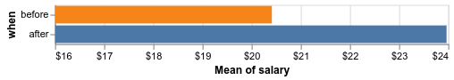

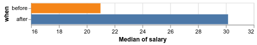

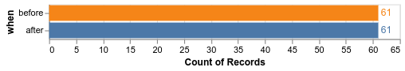

### ggplot

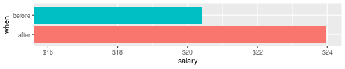

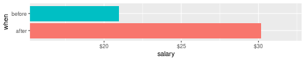

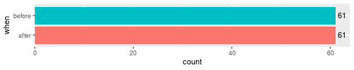

## My claim

As you can see, I have been able to produce a significant increase in the average salary for workers in my city. This high raise almost certainly entails that all (or almost all) workers are receiving a higher payment than what they were before I started to govern. But since I know you are going to ask me for more robust estimates, I have also provided the median increase (which is even more notable) and the number of workers in each group (so that you can see that the samples are balanced).

### Question 2.1

rubric={reasoning:2,writing:1}

- Explain which mistakes (if any) I have done in my plot and provide an interpretation of the data that is more correct than mine. Be brief and clear in your answer.
- You might have some ideas just from looking at my plot, but you will likely need to do some investigation yourself to answer this question fully. You can reference your improved plot as needed.

An increase in mean and median salaries does not imply that all or almost all citizens are earning a higher salary, because the mean and median do not show us the distibutions of salaries before and after. For example, there could be outliers, or a concentration of very low and lvery high salaries that result in similar means and medians. A better way to ensure that the salaries have actually increased amongst all citizens is to plot the salary distributions before and after, using violin or ridge plots.

### Question 2.2

rubric={accuracy:2}

#### Python

Recreate the Altair versions of my three plots in one cell each. Your plots should look as close as possible to mine in the images above.

```python
data = pd.read_csv("wages.csv")
data.head()
```

|  | when | salary |
| --- | --- | --- |
| 0 | after | 12.110028 |
| 1 | after | 12.873375 |
| 2 | after | 12.533566 |
| 3 | after | 11.646429 |
| 4 | after | 10.473839 |

```python
# YOUR ANSWER HERE
alt.Chart(data).mark_bar().encode(
    x = alt.X('mean(salary)',
              axis=alt.Axis(format='$,.0f', tickCount = 8), scale = alt.Scale(domain=[16, 24])),
    y = alt.Y('when', sort = ['before',  'after']),
    color = alt.Color('when', legend = None)
)
```

[interactive chart not shown]

```python
# YOUR ANSWER HERE
alt.Chart(data).mark_bar().encode(
    x = alt.X('median(salary)', scale = alt.Scale(domain = [16, 32]), axis= alt.Axis(tickCount = 8)),
    y = alt.Y('when', sort = ['before',  'after']),
    color = alt.Color('when', legend = None)
)
```

[interactive chart not shown]

```python
# YOUR ANSWER HERE
bar = alt.Chart(data).mark_bar().encode(
    x = alt.X('count()', axis = alt.Axis(tickCount = 13), scale = alt.Scale(domain = [0, 65])),
    y = alt.Y('when', sort = ['before',  'after']),
    color = alt.Color('when', legend = None)
)

bar + bar.mark_text(
    dx = 7
).encode(text='count()')
```

[interactive chart not shown]

### Question 2.3

rubric={accuracy:2}

#### R

Recreate my ggplot version of the plot. Your plot should look as close as possible to mine in the image above.

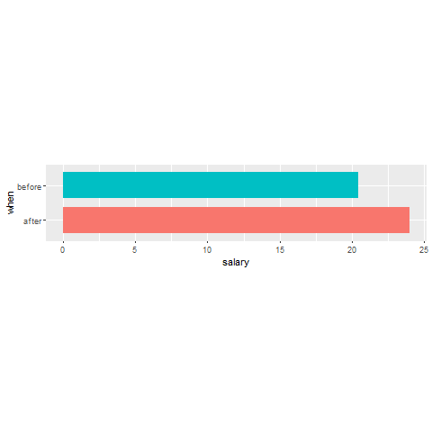

```python
%%R
# YOUR ANSWER HERE

data <- read.csv("wages.csv")

mean <- data %>% group_by(when) %>%
  summarise(value = mean(salary, na.rm = TRUE))

ggplot(mean, aes(x = value, y = when, fill = when)) +geom_col(width = 0.75) +
  scale_fill_manual(values = c(before = "#00BFC4", after = "#F8766D"), guide = "none") +
  labs(x = "salary", y = "when") + theme(aspect.ratio = 0.2)
```

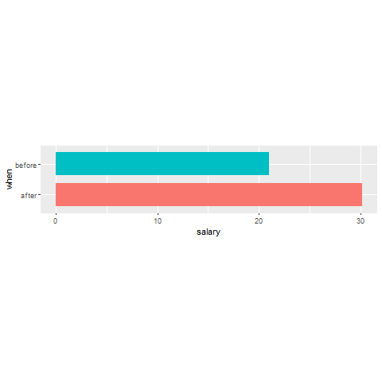

```python
%%R
# YOUR ANSWER HERE
med_df <- data %>%
    group_by(when) %>%
    summarise(value = median(salary, na.rm = TRUE))

ggplot(med_df, aes(x = value, y = when, fill = when)) +geom_col(width = 0.75) +
  scale_fill_manual(values = c(before = "#00BFC4", after = "#F8766D"), guide = "none") +
  labs(x = "salary", y = "when") +theme(aspect.ratio = 0.2)
```

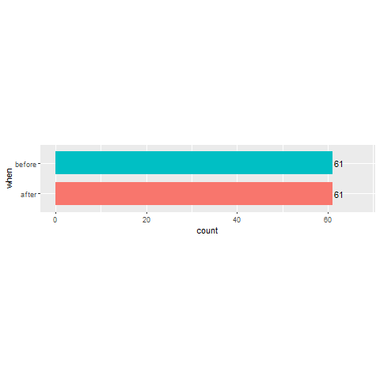

```python
%%R
# YOUR ANSWER HERE

count <- data %>%count(when, name = "value")

ggplot(count, aes(x = value, y = when, fill = when)) +geom_col(width = 0.75) +
  geom_text(aes(label = value), hjust = -0.15, size = 4) +xlim(0, max(count$value) * 1.1) +
  scale_fill_manual(values = c(before = "#00BFC4", after = "#F8766D"), guide = "none") +
  labs(x = "count", y = "when") +theme(aspect.ratio = 0.2)
```

### Question 2.4

rubric={viz:2}

#### Python

Improve my Altair plots. Chose the best type of plot to accurately reveal what the data looks like. Design the plot to be an effective plot for communication purposes, this includes proper figure size, axis/figure titles, font sizes, colors, etc. You can either make a single or several plots, depending on what you think is needed.

```python
# YOUR ANSWER HERE
violins =  alt.Chart(data).transform_density(
    'salary',
    as_ = ['salary', 'density'],
    extent=[5,50],
    groupby = ['when']
).mark_area(orient="horizontal").encode(
    y='salary',
    color = 'when:N',
    x=alt.X(
        'density:Q',
        stack='center',
        impute=None,
        title=None,
        axis=alt.Axis(labels=False, values=[0],grid=False, ticks=True),
    )
)

chart = alt.layer(
    violins,
    alt.Chart(data).mark_rule().encode(
        y='mean(salary)',
        x=alt.X(),
        color=alt.value('black')),
    alt.Chart(data).mark_rule().encode(
        y= alt.Y('median(salary)', title = "Salary"),
        x=alt.X(),
        color=alt.value('red')),
).properties(
    width = 250,
    height = 300
).facet(
    column=alt.Column(
        'when:N',
        header=alt.Header(
            titleOrient='bottom',
            labelOrient='bottom',
            labelPadding=0,
        )
    )
).configure_facet(
    spacing=0
).configure_view(
    stroke=None
).configure_axis(
    titleFontSize = 30,
    labelFontSize = 30
).configure_legend(
    titleFontSize = 30,
    labelFontSize = 30
)

chart
```

[interactive chart not shown]

## Chart Above:

### Question 2.5

rubric={viz:2}

#### R

Improve my ggplot plot. Chose the best type of plot to accurately reveal what the data looks like. Design the plot to be an effective plot for communication purposes, this includes proper figure size, axis/figure titles, font sizes, colors, etc. You can either make a single or several plots, depending on what you think is needed.

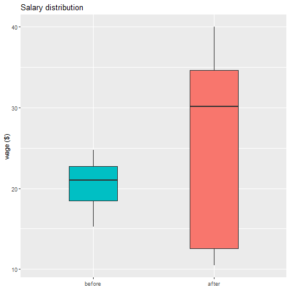

```python
%%R
# YOUR ANSWER HERE
data$when <- factor(data$when, levels = c("before", "after"))

ggplot(data, aes(x = when, y = salary, fill = when)) +
  geom_boxplot(width = 0.40, outlier.alpha = 0.25) +
  scale_fill_manual(values = c(before = "#00BFC4", after = "#F8766D"), guide = "none") +
  labs(title = "Salary distribution", x = NULL,y = "wage ($)")
```

# 3. Guns to the people

## The data

The `guns-r-us.csv` dataset contains yearly data for the number of murders by firearms in Florida.

[figure not shown]

## My plots

### Altair

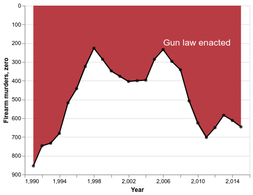

### ggplot

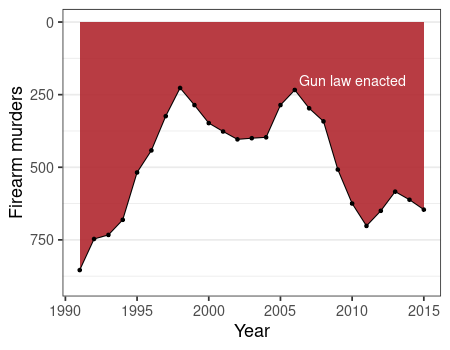

## My claim

As you can see, just after the gun law in Florida was enacted, deaths from firearms plummeted. I don't really think there is much else to discuss here.

### Question 3.1

rubric={reasoning:2,writing:1}

- Explain which mistakes (if any) I have done in my plot and provide an interpretation of the data that is more correct than mine. Be brief and clear in your answer.
- You might have some ideas just from looking at my plot, but you will likely need to do some investigation yourself to answer this question fully. You can reference your improved plot as needed.

The problem with the graph is that the y axis (number of gun deaths) is plotted in reverse, making it appear as though gun deaths plummeted after the law was enacted. In reality, the opposite is actually true, gun deaths actually increased after the law was enacted. I think the plot would be perfect to interpret if the y axis was simply just ordered in its regular (not reverse) order, then we could see the real trend.

### Question 3.2

rubric={accuracy:2}

#### Python

Recreate the Altair version of the plot. Your plot should look as close as possible to mine in the image above.

```python
data = pd.read_csv("guns-r-us.csv")
data.head()
```

|  | Year | Firearm murders |
| --- | --- | --- |
| 0 | 1991 | 854 |
| 1 | 1992 | 747 |
| 2 | 1993 | 733 |
| 3 | 1994 | 681 |
| 4 | 1995 | 518 |

```python
# YOUR ANSWER HERE
#values = [1990, 1994, 1998, 2002, 2006, 2010,2014]
chart = alt.Chart(data).mark_line(color = "black").encode(
    x = alt.X(
        'Year',
        axis = alt.Axis(tickCount = 13,
        grid = False,
                        labelExpr="datum.value % 2 == 0 ? datum.label : null",
        )
    ),
    y = alt.Y('Firearm murders:Q', scale = alt.Scale(domain=[0,900], reverse = True), axis = alt.Axis(tickCount = 9),
              title = "Firearm murders, zero"),
    #color = alt.Value("black")

)

background = alt.Chart(data).mark_area(opacity=0.3).encode(
    x='Year',
    y=alt.Y('price', scale=alt.Scale(domain=[0, 1000])), # Set a fixed domain
    color=alt.condition(
        "datum.price > 400",
        alt.value("red"),  # Red if price > 400
        alt.value("white") # White otherwise (or another color/transparent)
    )
)

(chart + chart.mark_area(color = "darkred") +
 chart.mark_circle(color="black", size = 50) + chart.mark_text(fontSize = 20, dy = -60, color = 'White', text = "Gun law enacted").transform_filter(alt.datum['Year'] == 2005)).properties(
    width = 600,
    height = 500
).configure_axis(
    titleFontSize = 30,
    labelFontSize = 15
)
```

[interactive chart not shown]

### Question 3.3

rubric={accuracy:2}

#### R

Recreate my ggplot version of the plot. Your plot should look as close as possible to mine in the image above.

```
In addition: Warning message:
Using `size` aesthetic for lines was deprecated in ggplot2 3.4.0.
i Please use `linewidth` instead.
```

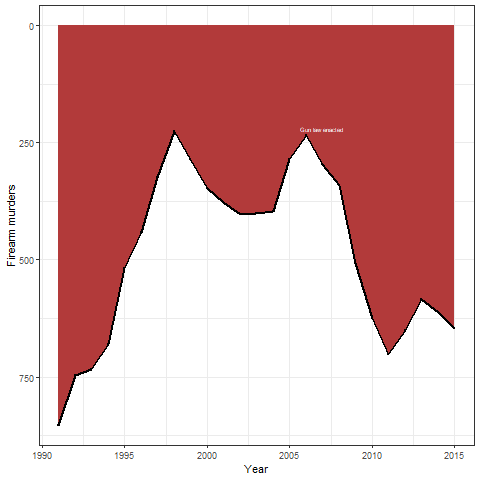

```python
%%R
# YOUR ANSWER HERE

d <- read.csv("guns-r-us.csv")
d
d$year    <- d$Year
d$murders <- d$Firearm.murders

law_yr <- 2006
ggplot(d, aes(x = year, y = murders)) +
  geom_ribbon(aes(ymin = murders, ymax = 0), fill = "#b23a3a") +
  geom_line(color = "black", size = 0.9) +
  geom_point(color = "black", size = 0.8) +
  annotate("text", x = law_yr + 1, y = 220,
           label = "Gun law enacted", color = "white", size = 2) +
  scale_y_reverse(breaks = c(0, 250, 500, 750)) +
  scale_x_continuous(breaks = c(1990, 1995, 2000, 2005, 2010, 2015)) +
  labs(x = "Year", y = "Firearm murders") +
  theme_bw()
```

### Question 3.4

rubric={viz:2}

#### Python

Improve my Altair plot. Chose the best type of plot to accurately reveal what the data looks like. Design the plot to be an effective plot for communication purposes, this includes proper figure size, axis/figure titles, font sizes, colors, etc.

```python
# YOUR ANSWER HERE

chart = alt.Chart(data).mark_line(color = "black").encode(
    x = alt.X(
        'Year',
        axis = alt.Axis(tickCount = 13,
                           labelExpr="datum.value % 2 == 0 ? datum.label : null")),
    y = alt.Y('Firearm murders:Q', scale = alt.Scale(domain=[0,900]), axis = alt.Axis(tickCount = 9),
              title = "Firearm murders"),
    #color = alt.Value("black")

)

(chart + chart.mark_circle(color="black", size = 50)
    +chart.mark_text(fontSize = 20, dy = 0, color = 'red', text = "Gun law enacted").transform_filter(alt.datum['Year'] == 2005)
).properties(
    title = alt.TitleParams("Year vs Firearm Murders in Florida",
                            anchor = "start",
    subtitle = "Gun Law enacted in 2005"),
    width = 600,
    height = 500
).configure_axis(
    titleFontSize = 30,
    labelFontSize = 15
).configure_title(fontSize = 40, subtitleFontSize = 23)
```

[interactive chart not shown]

### Question 3.5

rubric={viz:2}

#### R

Improve my ggplot plot. Chose the best type of plot to accurately reveal what the data looks like. Design the plot to be an effective plot for communication purposes, this includes proper figure size, axis/figure titles, font sizes, colors, etc.

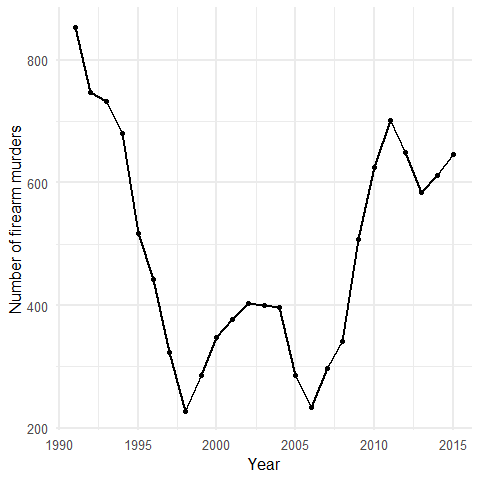

```python
%%R
# YOUR ANSWER HERE

ggplot(d, aes(x = Year, y = Firearm.murders)) +
  geom_line(size = 1) +
  geom_point(size = 2) +
  labs(
    x = "Year",
    y = "Number of firearm murders"
  ) +
  theme_minimal(base_size = 16) +
  theme(plot.title = element_text(face = "bold"))
```

# My approval ratings are astronomical

## The data

The (fictional) `state-comparison.csv` dataset contains a sample of voters from my state and a neighboring state of similar socioeconomic standard. Voters in each state were asked to rate their approval of the state's mayor on a scale from 0 - 10,000.

## My plots

### Altair

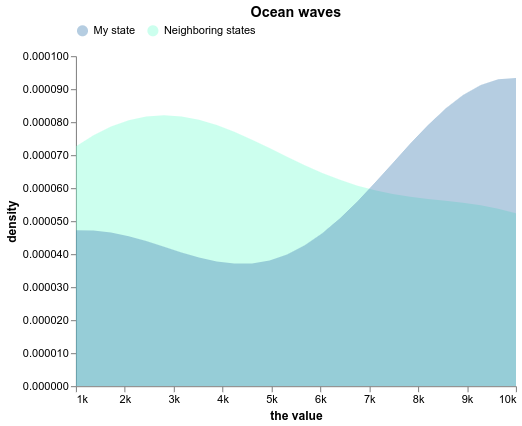

### ggplot

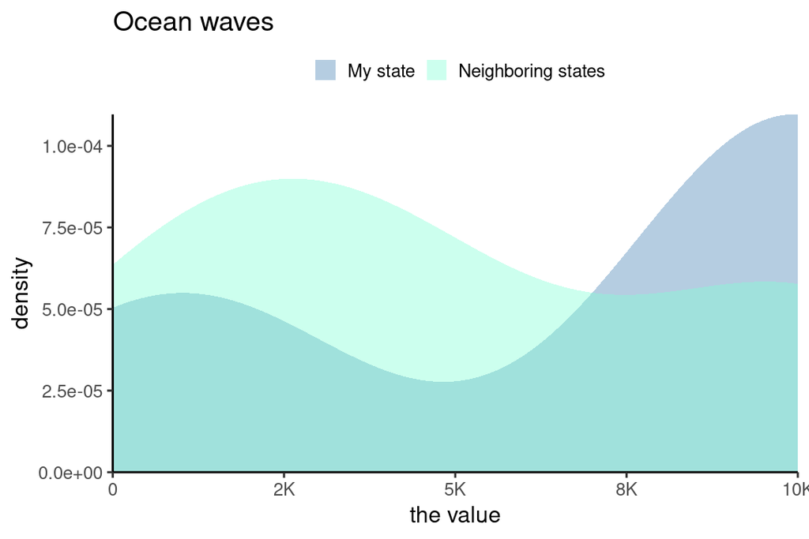

## My claim

My approval ratings are through the roof! I am clearly doing a better job than my colleague and competitor next doors. And as you can see we sampled enough people to get smooth curves, which means that this difference is both likely to be statistically significant and the magnitude is just too big to ignore. There seems to be a few bores on the lower end of the spectrum, but can't win them all I guess. Do you want a 10k approval rating future? Vote Ostblom in 2020!

### Question 4.1

rubric={reasoning:2,writing:1}

- Explain which mistakes (if any) I have done in my plot and provide an interpretation of the data that is more correct than mine. Be brief and clear in your answer.
- You might have some ideas just from looking at my plot, but you will likely need to do some investigation yourself to answer this question fully. You can reference your improved plot as needed.

The overlapping categories and colors can make it confusing to compare the categories and analyze each one individually. A better option would be to have them not overlapping, like in a ridgeline plot.

### Question 4.2

rubric={accuracy:2}

#### Python

Recreate the Altair version of the plot. Your plot should look as close as possible to mine in the image above.

```python
data = pd.read_csv("state-comparison.csv")
data.head()
```

|  | where | the value |
| --- | --- | --- |
| 0 | Neighboring states | 1000 |
| 1 | Neighboring states | 4100 |
| 2 | Neighboring states | 10000 |
| 3 | My state | 1000 |
| 4 | My state | 10000 |

```python
# YOUR ANSWER HERE

alt.Chart(data).transform_density(
    'the value',
    as_=['the value', 'density'],
    groupby = ['where']
).mark_area(opacity = 0.3).encode(
    x= alt.X("the value:Q", axis = alt.Axis(tickCount = 10, format='~s')),
    y= alt.Y('density:Q', stack = None, axis = alt.Axis(tickCount = 10, format = ',.6f')),
    color = alt.Color('where', scale = alt.Scale(domain = ['My state', 'Neighboring states'], range=['darkblue', 'lightblue']))
).properties(
    title = "Ocean waves",
    width = 800,
    height = 600
).configure_axis(
    grid = False,
    titleFontSize = 20,
    labelFontSize = 14
).configure_title(
    fontSize = 30
).configure_legend(
    title = None,
    orient = "top",
    labelFontSize = 20,
    labelLimit = 0
)
```

[interactive chart not shown]